# rosynekp_lab01

## **Lab 01 - Data Cleaning**

Paige Rosynek, 12.6.2022

### **Introduction**

In this lab, we will be exploring the process of loading, analyzing, and cleaning a dataset. The dataset we will be using contains real estate transaction data from properties located in Sacremento, California. The goal of this lab is to gain familiarity with the Pandas library, as well as produce a "cleaned" version of the original dataset. Throughout this lab, we will be using data visualization as well as statistical summaries to communicate trends and findings in the dataset to support our analysis.

Import libraries

```python
import pandas as pd
import matplotlib.pyplot as plt
import seaborn as sns
```

### **1. Loading the Data & Initial Assessment**

Load the Sacramentorealestatetransactions.csv file as a DataFrame

```python
df = pd.read_csv('./data/Sacramentorealestatetransactions.csv')
```

Preview the data

```python
df.head()
```

|  | street | city | zip | state | beds | baths | sq__ft | type | sale_date | price | latitude | longitude |
| --- | --- | --- | --- | --- | --- | --- | --- | --- | --- | --- | --- | --- |
| 0 | 3526 HIGH ST | SACRAMENTO | 95838 | CA | 2 | 1 | 836 | Residential | Wed May 21 00:00:00 EDT 2008 | 59222 | 38.631913 | -121.434879 |
| 1 | 51 OMAHA CT | SACRAMENTO | 95823 | CA | 3 | 1 | 1167 | Residential | Wed May 21 00:00:00 EDT 2008 | 68212 | 38.478902 | -121.431028 |
| 2 | 2796 BRANCH ST | SACRAMENTO | 95815 | CA | 2 | 1 | 796 | Residential | Wed May 21 00:00:00 EDT 2008 | 68880 | 38.618305 | -121.443839 |
| 3 | 2805 JANETTE WAY | SACRAMENTO | 95815 | CA | 2 | 1 | 852 | Residential | Wed May 21 00:00:00 EDT 2008 | 69307 | 38.616835 | -121.439146 |
| 4 | 6001 MCMAHON DR | SACRAMENTO | 95824 | CA | 2 | 1 | 797 | Residential | Wed May 21 00:00:00 EDT 2008 | 81900 | 38.519470 | -121.435768 |

The data set contains 12 columns with a total of 985 rows or entries. The inferred types of each of the columns is shown below. It can be observed that the columns that contain string data have the data type 'object'. The following columns are have integer types: zip, beds, baths, sq__ft, and price. The latitiude and longitude columns have the data type of float. From the non-null count column of the data summary below, we can conclude that none of the columns have null values based on the fact that we know there are 985 total entries and the non-null count for each of the columns is 985 which means that there are no null values in the data set.

```python
df.info()
```

```
<class 'pandas.core.frame.DataFrame'>
RangeIndex: 985 entries, 0 to 984
Data columns (total 12 columns):
 #   Column     Non-Null Count  Dtype
---  ------     --------------  -----
 0   street     985 non-null    object
 1   city       985 non-null    object
 2   zip        985 non-null    int64
 3   state      985 non-null    object
 4   beds       985 non-null    int64
 5   baths      985 non-null    int64
 6   sq__ft     985 non-null    int64
 7   type       985 non-null    object
 8   sale_date  985 non-null    object
 9   price      985 non-null    int64
 10  latitude   985 non-null    float64
 11  longitude  985 non-null    float64
dtypes: float64(2), int64(5), object(5)
memory usage: 92.5+ KB
```

### **2. Representing Categorical Variables**

Count the number of unique values for:

- streets
- zip codes
- beds

Unique values for 'street' column

```python
df['street'].value_counts()
```

```
8306 CURLEW CT         2
4734 14TH AVE          2
1223 LAMBERTON CIR     2
7 CRYSTALWOOD CIR      2
3526 HIGH ST           1
                      ..
2981 WRINGER DR        1
8616 ROCKPORTE CT      1
4128 HILL ST           1
1409 47TH ST           1
3882 YELLOWSTONE LN    1
Name: street, Length: 981, dtype: int64
```

```python
df['street'].nunique()
```

```
981
```

It can be observed that there are 981 unique street values out of the 985 entries of the data set. I think it makes more sense to make 'street' a categorical variable and not an integer variable beacause street names are represented by strings and if you were to use an integer variable to represent this data you would have to create a key that corresponds to each street.

Unique values for 'zip' column

```python
df['zip'].value_counts()
```

```
95648    72
95823    61
95828    45
95758    44
95838    37
         ..
95619     1
95614     1
95690     1
95633     1
95722     1
Name: zip, Length: 68, dtype: int64
```

```python
df['zip'].nunique()
```

```
68
```

It can be observed that there are 68 unique zip codes in the dataset. I think that it is more appropriate to make 'zip' a categorical variable because although zip codes are represented by numbers, they are not quantitative. There is no ordering or meaning to a higher or lower zip code value so it doesn't make sense to make the column an integer variable. Thus, it makes more sense to make zip code a categorical variable because many houses may share the same zip code.

Unique values for 'beds' column

```python
df['beds'].value_counts()
```

```
3    413
4    258
2    133
0    108
5     59
1     10
6      3
8      1
Name: beds, dtype: int64
```

```python
df['beds'].nunique()
```

```
8
```

It can be observed that there are 8 unique values for the 'beds' column. I think it is more appropriate to make 'beds' an integer variable because the integer value represents the number of bedrooms in a house. This means that the variable it is qualitative and should be represented as such using an integer variable, not a categorical variable. In addition, we know that there can be a minimum and maximum number of bedrooms across the data set which also indicates it should be an integer variable.

Convert the following columns into categorical variables:

- city
- state
- zip
- beds
- bath
- type

```python
to_convert = ['city', 'state', 'zip', 'beds', 'baths', 'type']
df[to_convert] = df[to_convert].astype('category')
```

Verify the data type for the columns are now 'category'

```python
df.info()
```

```
<class 'pandas.core.frame.DataFrame'>
RangeIndex: 985 entries, 0 to 984
Data columns (total 12 columns):
 #   Column     Non-Null Count  Dtype
---  ------     --------------  -----
 0   street     985 non-null    object
 1   city       985 non-null    category
 2   zip        985 non-null    category
 3   state      985 non-null    category
 4   beds       985 non-null    category
 5   baths      985 non-null    category
 6   sq__ft     985 non-null    int64
 7   type       985 non-null    category
 8   sale_date  985 non-null    object
 9   price      985 non-null    int64
 10  latitude   985 non-null    float64
 11  longitude  985 non-null    float64
dtypes: category(6), float64(2), int64(2), object(2)
memory usage: 56.9+ KB
```

### **3. Exploring Continuous Variables**

Plot histograms of the square footage, latitudes, and longitudes

Square Footage

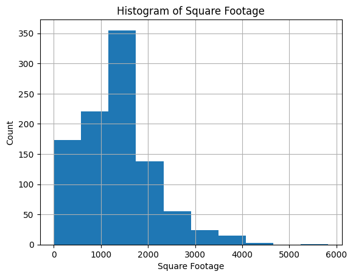

```python
ax = df['sq__ft'].hist()
plt.title('Histogram of Square Footage')
plt.ylabel('Count')
plt.xlabel('Square Footage')
```

Latitude

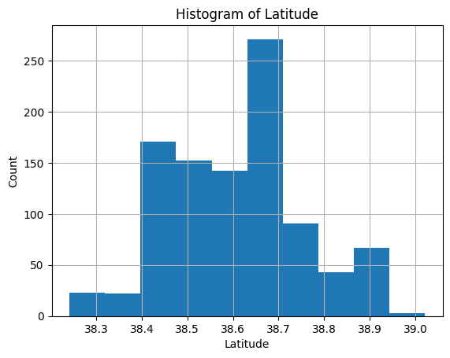

```python
ax = df['latitude'].hist()
plt.title('Histogram of Latitude')
plt.ylabel('Count')
plt.xlabel('Latitude')
```

Longitude

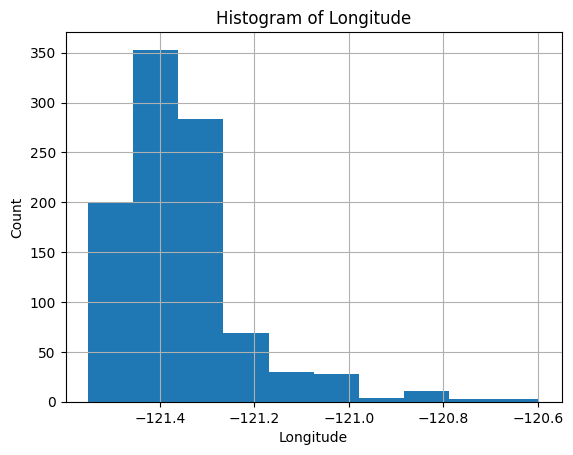

```python
ax = df['longitude'].hist()
plt.title('Histogram of Longitude')
plt.ylabel('Count')
plt.xlabel('Longitude')
```

One "odd" pattern I found in the histograms above is that there are some properties that have a square footage of 0. This most likely indicates that these properties are empty lots.

### **4. Exploring Categorical Variables**

Plot the following variables as bar plots:

- beds
- baths
- type
- state
- city
- zip code

Beds

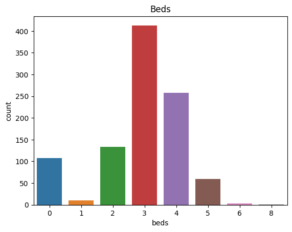

```python
sns.countplot(x='beds', data=df)
plt.title('Beds')
```

Baths

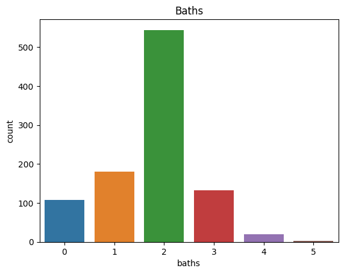

```python
sns.countplot(x='baths', data=df)
plt.title('Baths')
```

Type

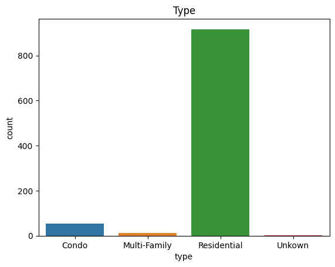

```python
sns.countplot(x='type', data=df)
plt.title('Type')
```

State

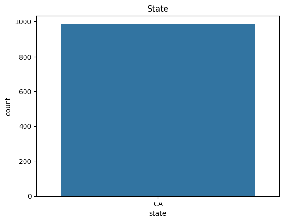

```python
sns.countplot(x='state', data=df)
plt.title('State')
```

City

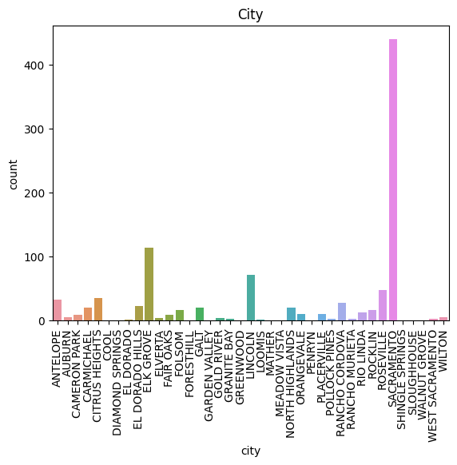

```python
chart = sns.countplot(x='city', data=df)
chart.set_xticklabels(chart.get_xticklabels(), rotation=90)
plt.title('City')
```

Zip

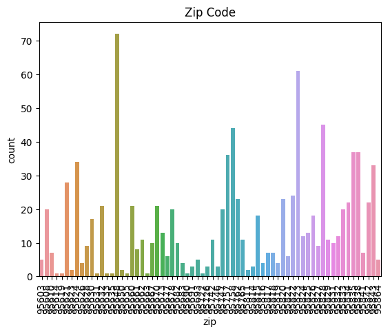

```python
chart = sns.countplot(x='zip', data=df)
chart.set_xticklabels(chart.get_xticklabels(), rotation=90)
plt.title('Zip Code')
```

One "odd" pattern in the bar plot for beds and bath is that there a some properties purchased that have 0 beds and/or baths. A property with 0 beds could mean that the property is not a residential property or that the property is an empty lot. A property with 0 baths is most likely an empty lot in which there would be 0 beds and 0 baths.

### **5. Engineering New Variables - Part I**

Create a new boolean variable called 'empty_lot' that is true if the square footage is 0 and false otherwise

```python
is_empty = lambda x: True if x == 0 else False
empty_lot = df['sq__ft'].map(is_empty)
```

Verify the new variable

```python
empty_lot.tail(20)
```

```
965    False
966     True
967    False
968    False
969    False
970     True
971    False
972    False
973     True
974    False
975    False
976    False
977    False
978    False
979    False
980    False
981    False
982    False
983    False
984    False
Name: sq__ft, dtype: bool
```

```python
print(df['sq__ft'].iloc[965:967])
print(empty_lot.iloc[965:967])
```

```
965    1418
966       0
Name: sq__ft, dtype: int64
965    False
966     True
Name: sq__ft, dtype: bool
```

Add this feature to the dataframe

```python
df['empty_lot'] = empty_lot
```

```python
df.head()
```

|  | street | city | zip | state | beds | baths | sq__ft | type | sale_date | price | latitude | longitude | empty_lot |
| --- | --- | --- | --- | --- | --- | --- | --- | --- | --- | --- | --- | --- | --- |
| 0 | 3526 HIGH ST | SACRAMENTO | 95838 | CA | 2 | 1 | 836 | Residential | Wed May 21 00:00:00 EDT 2008 | 59222 | 38.631913 | -121.434879 | False |
| 1 | 51 OMAHA CT | SACRAMENTO | 95823 | CA | 3 | 1 | 1167 | Residential | Wed May 21 00:00:00 EDT 2008 | 68212 | 38.478902 | -121.431028 | False |
| 2 | 2796 BRANCH ST | SACRAMENTO | 95815 | CA | 2 | 1 | 796 | Residential | Wed May 21 00:00:00 EDT 2008 | 68880 | 38.618305 | -121.443839 | False |
| 3 | 2805 JANETTE WAY | SACRAMENTO | 95815 | CA | 2 | 1 | 852 | Residential | Wed May 21 00:00:00 EDT 2008 | 69307 | 38.616835 | -121.439146 | False |
| 4 | 6001 MCMAHON DR | SACRAMENTO | 95824 | CA | 2 | 1 | 797 | Residential | Wed May 21 00:00:00 EDT 2008 | 81900 | 38.519470 | -121.435768 | False |

Create a count (bar) plot for the empty_lot variable

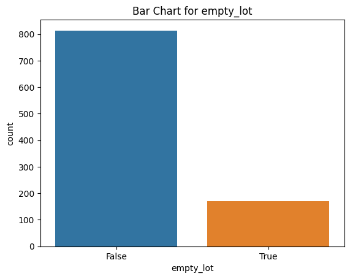

```python
sns.countplot(data=df, x='empty_lot')
plt.title('Bar Chart for empty_lot')
```

### **6. Engineering New Variables - Part II**

Count the number of unique values for the addresses (streets).

```python
df['street'].nunique()
```

```
981
```

There are 981 unique street values out of the total number of entries of 985, which means almost every property in the data set has a unique address. Since there is a high number of unique streets, this feature is not useful for a ML model in its current form because for the most part it only describes a single (entry) property which won't generalize to unseen data with a ML model.

Using the head() command, look at the first 20 records to identify address patterns.

```python
df.head(20)
```

|  | street | city | zip | state | beds | baths | sq__ft | type | sale_date | price | latitude | longitude | empty_lot |
| --- | --- | --- | --- | --- | --- | --- | --- | --- | --- | --- | --- | --- | --- |
| 0 | 3526 HIGH ST | SACRAMENTO | 95838 | CA | 2 | 1 | 836 | Residential | Wed May 21 00:00:00 EDT 2008 | 59222 | 38.631913 | -121.434879 | False |
| 1 | 51 OMAHA CT | SACRAMENTO | 95823 | CA | 3 | 1 | 1167 | Residential | Wed May 21 00:00:00 EDT 2008 | 68212 | 38.478902 | -121.431028 | False |
| 2 | 2796 BRANCH ST | SACRAMENTO | 95815 | CA | 2 | 1 | 796 | Residential | Wed May 21 00:00:00 EDT 2008 | 68880 | 38.618305 | -121.443839 | False |
| 3 | 2805 JANETTE WAY | SACRAMENTO | 95815 | CA | 2 | 1 | 852 | Residential | Wed May 21 00:00:00 EDT 2008 | 69307 | 38.616835 | -121.439146 | False |
| 4 | 6001 MCMAHON DR | SACRAMENTO | 95824 | CA | 2 | 1 | 797 | Residential | Wed May 21 00:00:00 EDT 2008 | 81900 | 38.519470 | -121.435768 | False |
| 5 | 5828 PEPPERMILL CT | SACRAMENTO | 95841 | CA | 3 | 1 | 1122 | Condo | Wed May 21 00:00:00 EDT 2008 | 89921 | 38.662595 | -121.327813 | False |
| 6 | 6048 OGDEN NASH WAY | SACRAMENTO | 95842 | CA | 3 | 2 | 1104 | Residential | Wed May 21 00:00:00 EDT 2008 | 90895 | 38.681659 | -121.351705 | False |
| 7 | 2561 19TH AVE | SACRAMENTO | 95820 | CA | 3 | 1 | 1177 | Residential | Wed May 21 00:00:00 EDT 2008 | 91002 | 38.535092 | -121.481367 | False |
| 8 | 11150 TRINITY RIVER DR Unit 114 | RANCHO CORDOVA | 95670 | CA | 2 | 2 | 941 | Condo | Wed May 21 00:00:00 EDT 2008 | 94905 | 38.621188 | -121.270555 | False |
| 9 | 7325 10TH ST | RIO LINDA | 95673 | CA | 3 | 2 | 1146 | Residential | Wed May 21 00:00:00 EDT 2008 | 98937 | 38.700909 | -121.442979 | False |
| 10 | 645 MORRISON AVE | SACRAMENTO | 95838 | CA | 3 | 2 | 909 | Residential | Wed May 21 00:00:00 EDT 2008 | 100309 | 38.637663 | -121.451520 | False |
| 11 | 4085 FAWN CIR | SACRAMENTO | 95823 | CA | 3 | 2 | 1289 | Residential | Wed May 21 00:00:00 EDT 2008 | 106250 | 38.470746 | -121.458918 | False |
| 12 | 2930 LA ROSA RD | SACRAMENTO | 95815 | CA | 1 | 1 | 871 | Residential | Wed May 21 00:00:00 EDT 2008 | 106852 | 38.618698 | -121.435833 | False |
| 13 | 2113 KIRK WAY | SACRAMENTO | 95822 | CA | 3 | 1 | 1020 | Residential | Wed May 21 00:00:00 EDT 2008 | 107502 | 38.482215 | -121.492603 | False |
| 14 | 4533 LOCH HAVEN WAY | SACRAMENTO | 95842 | CA | 2 | 2 | 1022 | Residential | Wed May 21 00:00:00 EDT 2008 | 108750 | 38.672914 | -121.359340 | False |
| 15 | 7340 HAMDEN PL | SACRAMENTO | 95842 | CA | 2 | 2 | 1134 | Condo | Wed May 21 00:00:00 EDT 2008 | 110700 | 38.700051 | -121.351278 | False |
| 16 | 6715 6TH ST | RIO LINDA | 95673 | CA | 2 | 1 | 844 | Residential | Wed May 21 00:00:00 EDT 2008 | 113263 | 38.689591 | -121.452239 | False |
| 17 | 6236 LONGFORD DR Unit 1 | CITRUS HEIGHTS | 95621 | CA | 2 | 1 | 795 | Condo | Wed May 21 00:00:00 EDT 2008 | 116250 | 38.679776 | -121.314089 | False |
| 18 | 250 PERALTA AVE | SACRAMENTO | 95833 | CA | 2 | 1 | 588 | Residential | Wed May 21 00:00:00 EDT 2008 | 120000 | 38.612099 | -121.469095 | False |
| 19 | 113 LEEWILL AVE | RIO LINDA | 95673 | CA | 3 | 2 | 1356 | Residential | Wed May 21 00:00:00 EDT 2008 | 121630 | 38.689999 | -121.463220 | False |

It can be observed from the table that the last token in a street address is usually the street type. However, for addresses that have unit numbers, the street type is the third to last token in the address. For addresses with 'HIGHWAY' as the street type end in a digit so the second to last token is the street type. In addition, there are some addresses that do not have a street type or the street type is given in Spanish.

Write a function get_street_type(address) that will return the street type (as a string) of an address

```python
def get_street_type(address):
    address = address.upper()
    tokens = address.split(" ")

    street_type = tokens[-1]

    if tokens[-2] == 'UNIT':
        street_type = tokens[-3]
    elif tokens[-1].isdigit():
        street_type = tokens[-2]
    elif tokens[1] == 'AVENIDA' or tokens[1] == 'VISTA':
        street_type = tokens[1]


    return str(street_type)
```

Use that function to create a new categorical variable of street types

```python
df['street_type'] = df['street'].apply(get_street_type).astype('category')
```

Verify new variable 'street_type'

```python
df[['street', 'street_type']].head(10)
```

|  | street | street_type |
| --- | --- | --- |
| 0 | 3526 HIGH ST | ST |
| 1 | 51 OMAHA CT | CT |
| 2 | 2796 BRANCH ST | ST |
| 3 | 2805 JANETTE WAY | WAY |
| 4 | 6001 MCMAHON DR | DR |
| 5 | 5828 PEPPERMILL CT | CT |
| 6 | 6048 OGDEN NASH WAY | WAY |
| 7 | 2561 19TH AVE | AVE |
| 8 | 11150 TRINITY RIVER DR Unit 114 | DR |
| 9 | 7325 10TH ST | ST |

Count the unique elements and print them out

```python
df['street_type'].nunique()
```

```
22
```

```python
df['street_type'].value_counts()
```

```
WAY         303
DR          171
CT          126
CIR         113
ST           82
AVE          74
LN           47
RD           28
BLVD         13
PL           10
PKWY          7
CONEJO        1
BROADWAY      1
GRANDE        1
HIGHWAY       1
HL            1
AVENIDA       1
LOOP          1
TRAK          1
TRL           1
VISTA         1
WALK          1
Name: street_type, dtype: int64
```

Plot the street types as a count (bar) plot

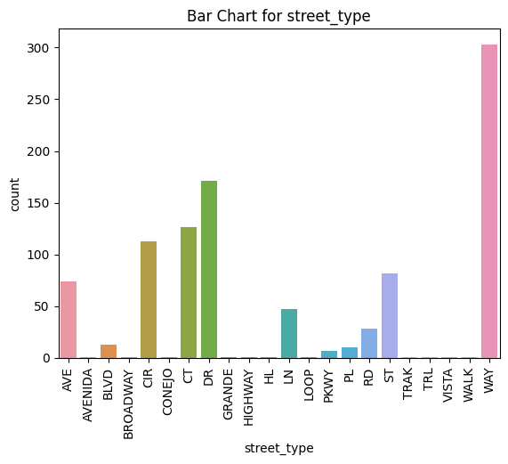

```python
chart = sns.countplot(data=df, x='street_type')
plt.title('Bar Chart for street_type')
chart.set_xticklabels(chart.get_xticklabels(), rotation=90)
plt.show()
```

### **7. Identifying Potential Label Variables**

```python
df.info()
```

```
<class 'pandas.core.frame.DataFrame'>
RangeIndex: 985 entries, 0 to 984
Data columns (total 14 columns):
 #   Column       Non-Null Count  Dtype
---  ------       --------------  -----
 0   street       985 non-null    object
 1   city         985 non-null    category
 2   zip          985 non-null    category
 3   state        985 non-null    category
 4   beds         985 non-null    category
 5   baths        985 non-null    category
 6   sq__ft       985 non-null    int64
 7   type         985 non-null    category
 8   sale_date    985 non-null    object
 9   price        985 non-null    int64
 10  latitude     985 non-null    float64
 11  longitude    985 non-null    float64
 12  empty_lot    985 non-null    bool
 13  street_type  985 non-null    category
dtypes: bool(1), category(7), float64(2), int64(2), object(2)
memory usage: 59.5+ KB
```

In general, integer valued columns are most likely good candidates for regression problems and categorical variables are good candidates for classfication problems. The variable price would be good output variable for a regression problem because it is an integer type and depends on the values of the other features. The variable 'type' would be a good output variable for a classification problem because it is a categorical variable and has only a few unique values to represent clases.

### **8. Identify and remove an outlier record from the dataset.**

Since we are looking for a data entry with the value 'unknown' we will check the categorical variables of the dataframe.

```python
df.describe(include='category')
```

|  | city | zip | state | beds | baths | type | street_type |
| --- | --- | --- | --- | --- | --- | --- | --- |
| count | 985 | 985 | 985 | 985 | 985 | 985 | 985 |
| unique | 39 | 68 | 1 | 8 | 6 | 4 | 22 |
| top | SACRAMENTO | 95648 | CA | 3 | 2 | Residential | WAY |
| freq | 439 | 72 | 985 | 413 | 544 | 917 | 303 |

First, we will check the unique value counts for column 'type'.

```python
df['type'].value_counts()
```

```
Residential     917
Condo            54
Multi-Family     13
Unkown            1
Name: type, dtype: int64
```

We see from the value counts for the 'type' variable that there is one entry in the column with the value 'Unkown', so we have to find the corresponding row in the dataframe with this value for 'type'.

Find outlier with type = 'Unkown'

```python
df[df['type'] == 'Unkown']
```

|  | street | city | zip | state | beds | baths | sq__ft | type | sale_date | price | latitude | longitude | empty_lot | street_type |
| --- | --- | --- | --- | --- | --- | --- | --- | --- | --- | --- | --- | --- | --- | --- |
| 757 | 6007 MARYBELLE LN | SHINGLE SPRINGS | 95682 | CA | 0 | 0 | 0 | Unkown | Fri May 16 00:00:00 EDT 2008 | 275000 | 38.64347 | -120.888183 | True | LN |

Outlier located at index 757

```python
df.index[df['type'] == 'Unkown']
```

```
Int64Index([757], dtype='int64')
```

Remove outlier with type = 'Unkown' at index 757

```python
df.drop(df[df['type'] == 'Unkown'].index, axis=0, inplace=True)
```

Verify outlier was removed

```python
df.iloc[757]
```

```
street                    9949 NESTLING CIR
city                              ELK GROVE
zip                                   95757
state                                    CA
beds                                      3
baths                                     2
sq__ft                                 1543
type                            Residential
sale_date      Fri May 16 00:00:00 EDT 2008
price                                275000
latitude                          38.397455
longitude                       -121.468391
empty_lot                             False
street_type                             CIR
Name: 758, dtype: object
```

### **9. Save the Cleaned Dataset**

Save the cleaned dataset to a .csv file

```python
df.to_csv('sacramento_real_estate_clean.csv', index=False)
```

### **Conclusion**

Throughout this lab, I was able to gain experience and a better understanding of the process of data cleaning. After analyzing the Sacremento dataset, we found that Pandas may not always infer the correct data types for columns when loading in the data, so we converted some of the columns like city, state, zip, beds, bath, and type to categorical variables. From plotting each of these variables with a bar chart we were able to gain insight into the number of occurrences of certain values for each column. The beds, baths, and sq_ft columns had some values that were 0, which in the context of our problem meant that the entry most likely represented an empty plot or a non-residential property. Thus, we added a new categorical column called 'empty_lot' that is true for any entry that has a square footage (sq_ft) of 0. One takeaway from this lab was that although there were no null values in the dataset, there was still outliers in our dataset that we had to remove; like in step 8 where we removed the data entry with the 'type' value of 'Unkown'. After completing the analysis of the data, it was concluded that this data set would work for a regression or classification problem to train a ML model. Categorical features make better candidates for classification problems and integer or float values make good candidates for regression problems.